# Activity Quality Prediction

Andres

Thursday, September 21, 2016

## Backround

Using devices such as Jawbone Up, Nike FuelBand, and Fitbit it is now possible to collect a large amount of data about personal activity relatively inexpensively. These type of devices are part of the quantified self movement – a group of enthusiasts who take measurements about themselves regularly to improve their health, to find patterns in their behavior, or because they are tech geeks. One thing that people regularly do is quantify how much of a particular activity they do, but they rarely quantify how well they do it. In this project, your goal will be to use data from accelerometers on the belt, forearm, arm, and dumbell of 6 participants. They were asked to perform barbell lifts correctly and incorrectly in 5 different ways. More information is available from the website here: http://groupware.les.inf.puc-rio.br/har (see the section on the Weight Lifting Exercise Dataset).

## Getting data

Training & test dataset download

```r
train_url <- 'https://d396qusza40orc.cloudfront.net/predmachlearn/pml-training.csv'
test_url <- 'https://d396qusza40orc.cloudfront.net/predmachlearn/pml-testing.csv'
train_filename <- 'pml-training.csv'
test_filename <- 'pml-testing.csv'

# If file does not exist download it into current working directory

if(!file.exists(test_filename))
    {
    download.file(test_url, test_filename)
    }

if(!file.exists(train_filename))
    {
    download.file(train_url, train_filename)
    }
```

Read in test and training dataset and make first insight.

```r
df_training <- read.csv(train_filename, sep = ',', header = TRUE, na.strings=c("NA",""))
df_testing <- read.csv(test_filename, sep = ',', header = TRUE, na.strings=c("NA",""))
dim(df_training)
```

```
## [1] 19622   160
```

```r
dim(df_testing)
```

```
## [1]  20 160
```

There are 19622 observations of 160 variables in training dataset and 20 observations and 160 variables in testing dataset.

## Cleaning data

Let’s remove preditctors which does not describe the activity (rowid ‘X’ and all timestamp columns, username and _window columns which describe time window (1s of data) and not exercise).

```r
rm_cols_train <- names(df_training) %in% c('X','raw_timestamp_part_1','raw_timestamp_part_2','cvtd_timestamp','user_name', 'new_window','num_window')
rm_cols_test <- names(df_testing) %in% c('X','raw_timestamp_part_1','raw_timestamp_part_2','cvtd_timestamp','user_name','new_window','num_window')
df_training <- df_training[!rm_cols_train]
df_testing <- df_testing[!rm_cols_test]
#summary(df_training)
```

```r
df_training_na <- df_training[colSums(is.na(df_training)) == 0]
df_testing_na <- df_testing[colSums(is.na(df_testing)) == 0]
```

Last step of data cleaning is to get rid of near zero variance variables. Let’s check whether there are such columns in our dataset

```r
nearZeroVar(df_training_na)
```

```
## integer(0)
```

```r
nearZeroVar(df_testing_na)
```

```
## integer(0)
```

```r
df_training_clean <- df_training_na
df_testing_clean <- df_testing_na
```

There were no near zero variance variables in data set. Data cleaning ends here. Summary:

There are 19622 observations of 53 variables in clean training dataset and 20 observations of 53 varibales in clean testing dataset.

## Data Splitting

Training dataset is split into two dataset (70% of data into training dataset and 30% into validation dataset) which enables to perform cross-validations step in our research.

```r
inTrain <- createDataPartition(df_training_clean$classe, p=0.7, list = FALSE)
training <- df_training_clean [inTrain,]
validation <- df_training_clean [-inTrain,]
```

## Model Fitting

Our task is to classify data (predict into which class every observation belongs) and we choose Gradient Boosting Machine for that task.

```r
model_gbm <- train(classe~., data=training, method = 'gbm')
```

When model is ready prediction on validation dataset is made.

```r
prediction_gbm <- predict(model_gbm,validation)
confusionMatrix(prediction_gbm, validation$classe)
```

```
## Confusion Matrix and Statistics
##
##           Reference
## Prediction    A    B    C    D    E
##          A 1652   33    1    0    0
##          B   11 1082   31    4   12
##          C    4   23  969   35   11
##          D    5    0   22  916   17
##          E    2    1    3    9 1042
##
## Overall Statistics
##
##                Accuracy : 0.9619
##                  95% CI : (0.9567, 0.9667)
##     No Information Rate : 0.2845
##     P-Value [Acc > NIR] : < 2.2e-16
##
##                   Kappa : 0.9518
##  Mcnemar's Test P-Value : 2.918e-06
##
## Statistics by Class:
##
##                      Class: A Class: B Class: C Class: D Class: E
## Sensitivity            0.9869   0.9500   0.9444   0.9502   0.9630
## Specificity            0.9919   0.9878   0.9850   0.9911   0.9969
## Pos Pred Value         0.9798   0.9491   0.9299   0.9542   0.9858
## Neg Pred Value         0.9948   0.9880   0.9882   0.9903   0.9917
## Prevalence             0.2845   0.1935   0.1743   0.1638   0.1839
## Detection Rate         0.2807   0.1839   0.1647   0.1556   0.1771
## Detection Prevalence   0.2865   0.1937   0.1771   0.1631   0.1796
## Balanced Accuracy      0.9894   0.9689   0.9647   0.9706   0.9800
```

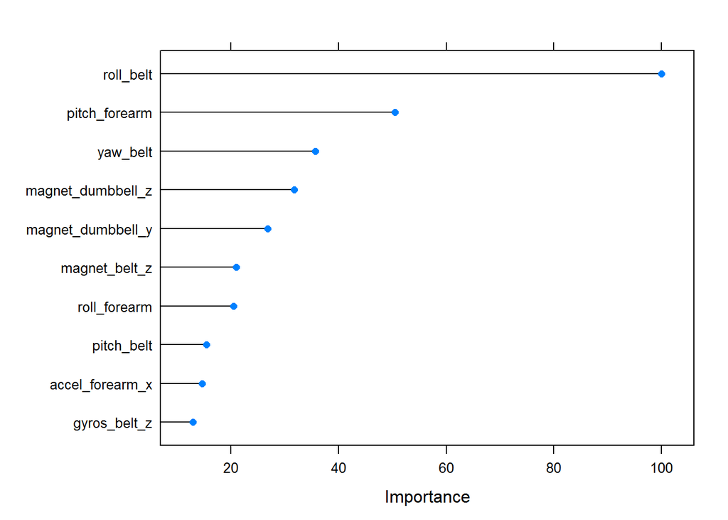

```r
plot(varImp(model_gbm), top = 10)
```